# Session 3: multivariate methods with R

Continuity from visualisation, GLMs and GLMMs

O Rodriguez de Rivera Ortega, PhD

University of Exeter

# 1 Session 3 overview

## 1.1 Where this session fits

In the previous sessions we moved through three related ideas:

1. **Data representation**: how do we see patterns in one, two or several variables?
2. **GLMs**: how do we model non-Gaussian responses such as binary and count data?
3. **GLMMs**: how do we model responses when observations are grouped or repeated?

This session moves from modelling a single response variable to understanding **many variables at once**.

The guiding question is:

> When each observation has many measurements, how can we simplify, visualise, classify or model the structure?

## 1.2 Learning outcomes

By the end of the 4–5 hour session, students should be able to:

- recognise common types of multivariate data;
- decide when PCA, clustering, discriminant analysis, NMDS, EFA or CLMMs are appropriate;
- prepare multivariate data for analysis in R;
- interpret ordination plots, cluster solutions and discriminant scores;
- explain the difference between exploratory and supervised multivariate methods;
- connect multivariate outputs to the modelling ideas from GLM and GLMM sessions.

# 2 Setup

## 2.1 Packages

```r
install.packages(c(
  "tidyverse", "palmerpenguins", "GGally", "corrplot", "cluster",
  "MASS", "vegan", "psych", "GPArotation", "ordinal", "broom"
))
```

```r
library(tidyverse)
library(palmerpenguins)
library(GGally)

theme_set(theme_minimal(base_size = 12))
```

# 3 What is multivariate data?

## 3.1 From univariate to multivariate questions

A univariate question focuses on one variable:

- What is the distribution of body mass?
- How many species are observed?
- How many counts occur in each treatment?

A bivariate question relates two variables:

- Does body mass increase with flipper length?
- Does probability of presence increase with elevation?

A multivariate question uses several variables together:

- Which combinations of traits separate penguin species?
- Do sites group into community types?
- Which environmental gradient explains changes in species composition?
- Can an ordinal response be modelled while accounting for repeated judges or observers?

## 3.2 A method map

| Question | Response/data type | Example method |
| --- | --- | --- |
| Reduce many continuous variables to a few axes | Continuous variables | PCA |
| Find natural groups without labels | Continuous or distance-based data | Clustering |
| Predict known groups from continuous variables | Labelled groups | LDA/QDA |
| Compare ecological communities | Species-by-site matrix | NMDS, PERMANOVA |
| Estimate latent constructs from questionnaires | Correlated items | EFA |
| Model ordered categories with grouping | Ordinal response + random effects | CLMM |

The same dataset can often be analysed in more than one way. The key is to match the method to the scientific question.

# 4 A shared teaching dataset

## 4.1 Palmer penguins as a running example

We will reuse `palmerpenguins` across several files to create continuity.

```r
penguins_clean <- palmerpenguins::penguins %>%
  tidyr::drop_na(
    species,
    island,
    sex,
    bill_length_mm,
    bill_depth_mm,
    flipper_length_mm,
    body_mass_g
  ) %>%
  dplyr::mutate(
    species = factor(species),
    island = factor(island),
    sex = factor(sex)
  )

penguin_traits <- penguins_clean %>%
  dplyr::select(
    bill_length_mm,
    bill_depth_mm,
    flipper_length_mm,
    body_mass_g
  )

dplyr::glimpse(penguins_clean)
```

```
## Rows: 333
## Columns: 8
## $ species           <fct> Adelie, Adelie, Adelie, Adelie, Adelie, Adelie, Adel…
## $ island            <fct> Torgersen, Torgersen, Torgersen, Torgersen, Torgerse…
## $ bill_length_mm    <dbl> 39.1, 39.5, 40.3, 36.7, 39.3, 38.9, 39.2, 41.1, 38.6…
## $ bill_depth_mm     <dbl> 18.7, 17.4, 18.0, 19.3, 20.6, 17.8, 19.6, 17.6, 21.2…
## $ flipper_length_mm <int> 181, 186, 195, 193, 190, 181, 195, 182, 191, 198, 18…
## $ body_mass_g       <int> 3750, 3800, 3250, 3450, 3650, 3625, 4675, 3200, 3800…
## $ sex               <fct> male, female, female, female, male, female, male, fe…
## $ year              <int> 2007, 2007, 2007, 2007, 2007, 2007, 2007, 2007, 2007…
```

```r
dplyr::glimpse(penguin_traits)
```

```
## Rows: 333
## Columns: 4
## $ bill_length_mm    <dbl> 39.1, 39.5, 40.3, 36.7, 39.3, 38.9, 39.2, 41.1, 38.6…
## $ bill_depth_mm     <dbl> 18.7, 17.4, 18.0, 19.3, 20.6, 17.8, 19.6, 17.6, 21.2…
## $ flipper_length_mm <int> 181, 186, 195, 193, 190, 181, 195, 182, 191, 198, 18…
## $ body_mass_g       <int> 3750, 3800, 3250, 3450, 3650, 3625, 4675, 3200, 3800…
```

## 4.2 Visual continuity from session 1

Before fitting any multivariate method, we still start with visualisation.

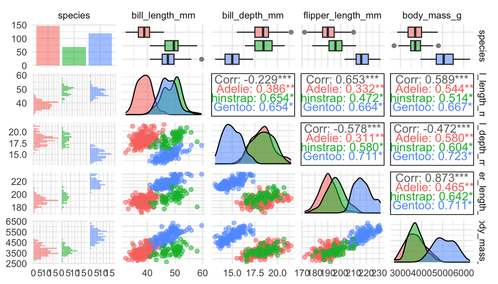

```r
penguins_clean %>%
  dplyr::select(species, bill_length_mm, bill_depth_mm, flipper_length_mm, body_mass_g) %>%
  GGally::ggpairs(mapping = aes(colour = species, alpha = 0.6))
```

## 4.3 Correlation structure

PCA, EFA and clustering are all sensitive to correlation and scaling.

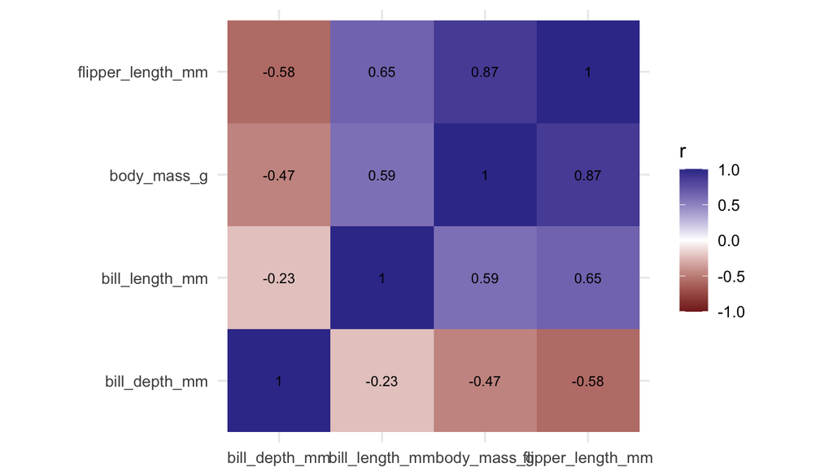

```r
cor_long <- penguin_traits %>%
  cor() %>%
  as.data.frame() %>%
  rownames_to_column("var1") %>%
  pivot_longer(-var1, names_to = "var2", values_to = "correlation")

ggplot(cor_long, aes(var1, var2, fill = correlation)) +
  geom_tile() +
  geom_text(aes(label = round(correlation, 2)), size = 3) +
  scale_fill_gradient2(limits = c(-1, 1)) +
  coord_equal() +
  labs(x = NULL, y = NULL, fill = "r")
```

## 4.4 Why scaling matters

Variables measured on larger numerical scales dominate distance-based methods unless they are standardised.

```r
raw_ranges <- penguin_traits %>%
  summarise(across(everything(), ~ max(.x) - min(.x))) %>%
  pivot_longer(everything(), names_to = "variable", values_to = "range")

raw_ranges
```

```
## # A tibble: 4 × 2
##   variable           range
##   <chr>              <dbl>
## 1 bill_length_mm      27.5
## 2 bill_depth_mm        8.4
## 3 flipper_length_mm   59
## 4 body_mass_g       3600
```

```r
traits_scaled <- penguin_traits %>%
  scale() %>%
  as.data.frame()

traits_scaled %>%
  summarise(across(everything(), list(mean = mean, sd = sd))) %>%
  pivot_longer(everything())
```

```
## # A tibble: 8 × 2
##   name                       value
##   <chr>                      <dbl>
## 1 bill_length_mm_mean     3.56e-16
## 2 bill_length_mm_sd       1   e+ 0
## 3 bill_depth_mm_mean      5.57e-16
## 4 bill_depth_mm_sd        1   e+ 0
## 5 flipper_length_mm_mean  1.84e-16
## 6 flipper_length_mm_sd    1   e+ 0
## 7 body_mass_g_mean       -9.31e-17
## 8 body_mass_g_sd          1   e+ 0
```

# 5 Choosing a method

## 5.1 Unsupervised versus supervised methods

**Unsupervised methods** do not use a known response label while fitting the structure.

Examples:

- PCA;
- clustering;
- NMDS;
- EFA.

**Supervised methods** use a known response or group label.

Examples:

- discriminant analysis;
- GLMs and GLMMs;
- CLMMs.

This distinction is important because it changes how we interpret the output.

## 5.2 Continuity with GLM/GLMM thinking

A multivariate output can become part of a later model.

Examples:

- use PC1 as a body-size index in a GLM;
- use cluster membership as an exploratory grouping variable;
- use NMDS1/NMDS2 scores as summaries of community composition;
- use factor scores as reduced-dimensional predictors;
- use CLMMs when the response is ordinal and repeated/grouped.

So the workflow is not separate from modelling. It often feeds into modelling.

# 6 Practical exercise

## 6.1 Exercise 1: method choice

For each question, choose a suitable method and justify your choice.

1. You have 12 correlated soil chemistry variables and want one or two gradients.
2. You have 40 sites and 80 species, and want to visualise community similarity.
3. You have penguin measurements and species labels, and want to predict species.
4. You have repeated ordinal ratings from observers, from 1 = low to 5 = high.
5. You have survey items designed to measure a smaller set of latent attitudes.

## 6.2 Exercise 2: prepare the data

Using `penguins_clean`, create:

1. a scaled continuous trait matrix;
2. a metadata table containing species, island and sex;
3. a correlation heatmap for the continuous traits.